# DNA de peixes: alinhamento e distância

Conhecimentos básicos para lidar com sequências de DNA, RNA e proteínas utilizando ferramentas de R

Data de Publicação

23 de outubro de 2026

**Dica**

**Nota:** Este material foi escrito para práticas em R usando o RStudio.

# Conceitos fundamentais

## Polímeros biológicos como **sequências**

**DNA**, **RNA** e **proteínas** são **polímeros** formados por **monômeros** ordenados:

- **DNA** e **RNA**: cadeias de **nucleotídeos**
- **Proteínas**: cadeias de **aminoácidos**

A **ordem** dos **monômeros** codifica informação biológica e determina **função** e **estrutura**: a **sequência** de **DNA** codifica **RNAs** e **proteínas**; a **sequência** de **aminoácidos** determina **estrutura tridimensional** das *proteínas* e sua atividade; a sequência de nucleotídeos de um RNA, codificador ou não de proteínas, pode determinar regiões de auto pareamentos, que resultam em estruturas secundárias e terciárias com capacidade catalítica, semelhantemente às proteínas.

## O formato *fasta*

O **fasta** armazena **sequências** (de **DNA**, **RNA** ou **proteínas**).

Como os nucleotídeos e aminoácidos são moléculas definidas e fácilmente representadas por letras, a *International Union of Pure and Applied Chemistry* [**IUPAC**](https://iupac.org/) padronizou o [código de uma letra](https://www.bioinformatics.org/sms2/iupac.html), que toda a área da *Bioinformática de sequências* utiliza em suas análises de *genética*, *genômica*, *transcriptômica*, *proteômica* e outras áras afins.

O arquivo **fasta** é muito simples, composto por múltiplas linhas que podem ser apenas de 2 tipos:

- **Cabeçalho**: linha iniciada por **>** com um **identificador único da sequência** e, opcionalmente, **metadados**.
- **Sequência**: linhas subsequentes com as **letras** do **alfabeto** correspondente (aminoácidos ou nucleotídeos).

**Exemplo (fasta de DNA):**

```
>seq1 organismo=Homo_sapiens gene=MT-ND1
ATGCCCTCGGCTTCTGGTAATACACCGCGGACATCGGCGTAAAGAGTGGTTAGGAAGTCTTTCAAACTACGGTTACGGAC
ATCGGCGTAAAGAGTGGTTAGGAAGTCTTTCAAACTATACGAATACGGACATCGGCGTAAAGAGTGGTTAGGAAGTCTTT
CAAACTACGGACATCGGCGTAAAGAGTGGTTAGGAAGTCTTTCAAACTAGGCCCAAGTTGATGAACATCGGCGTAAAAAG
TGGTTAGGAACAGAGCTAGATACTAAA
```

## Repositórios de sequências

Muitos *Bancos de Dados* são dedicados para o armazenamento de sequências de **DNA**, **RNA** e **proteínas**. O principal destes é o [*NCBI nucleotide*](https://www.ncbi.nlm.nih.gov/nucleotide/). Este banco guarda virtualmente todas sequências biológicas já registradas pela ciência, com livre acesso e possibilidade de download. Todo cientista que realiza algum estudo genético deve depositar os dados genéticos lá, para contribuir para o conhecimento coletivo.

# Prática

Baixar o script desta prática (.R)

Vamos conhecer um arquivo **fasta**? Siga as instruções a seguir no seu **Rstudio**. Copie, cole e execute os comandos abaixo

## Preparativos

### Carregando pacotes

Todos pacotes públicos criados para o R são de livre acesso. Qualquer usuário poide baixar e instalar com poucos comandos. Existem vários repositórios de pacotes (*packages*) e na bioinforática utilizamos práticamente dois:

- [**CRAN**](https://cran.r-project.org/) **(pacotes “gerais” do R)**  
  Repositório amplo e genérico (estatística, web, gráficos, etc.). Publicação via *install.packages()*. Ciclo de versões **independente** entre pacotes; revisão é mais básica e não força integração entre eles.
- **Bioconductor** **(instalado/gerenciado via `BiocManager`)**  
  Ecossistema **focado em bioinformática/ômicas** (RNA-seq, ChIP-seq, variantes, anotação, análise de dados de sequenciamento, …). Apresenta larga padronização em formatos de resultados. Possui **annotation/data packages** (ex.: genomas, bancos de genes) e serviços como **AnnotationHub/ExperimentHub**. Tem **releases semestrais** sincronizadas com a versão do R e **checagem de compatibilidade** entre pacotes, visando reprodutibilidade.

#### CRAN - Instalando pacotes

```r
#instale apenas caso você ainda não tenha o pacote ----
#    DICA: só é preciso instalar cada pacote uma única vez


# lista de pacotes CRAN que você quer garantir instalados
cran_pkgs <- c("pheatmap",
               "stringr",
               "BiocManager",
               "ggseqlogo",
               "tidyverse",
               "RColorBrewer")

# instala apenas os que não estão presentes
for (pkg in cran_pkgs) {
  if (!requireNamespace(pkg, quietly = TRUE)) {
    install.packages(pkg)
  }
}
```

#### Bioconductor - Instalando pacotes

```r
#instale apenas caso você ainda não tenha o pacote ----
#    DICA: só é preciso instalar cada pacote uma única vez

# lista de pacotes Bioconductor
bio_pkgs <- c("Biostrings", "DECIPHER")

# instala apenas os que faltam
for (pkg in bio_pkgs) {
  if (!requireNamespace(pkg, quietly = TRUE)) {
    BiocManager::install(pkg, ask = FALSE, update = FALSE)
  }
}
```

#### Carregando pacotes

```r
# carregando pacotes ----
{
library("tidyverse")
library("Biostrings")
library("stringr")
library("dplyr")
library("DECIPHER")
library("tibble")
library("RColorBrewer")
library("pheatmap")
library("ggseqlogo")
}
```

> DICA: caso receba alguma mensagem de que o pacote não foi encontrado, você pode instalá-lo com:

```r
install.packages("pacote")
```

> DICA: Alguns pacotes de bioinformática são fornecidos pelo Bioconductor, e podem ser instalados com o gerenciador de pacotes *BiocManager*

```r
 install.packages("BiocManager")
BiocManager::install("pacote")
```

### Definindo seu diretório de trabalho

Para cada projeto, sempre crie uma pasta onde você vai salvar todos arquivos e scripts, assim você mantém seu trabalho sempre organizado. No comando abaixo, coloque dentro das aspas o caminho para o seu diretório de trabalho.

> DICA: Sempre utilize a tecla `TAB` para autocompletar os caminhos a partir do **~** ou **/** (ou ****, caso no windows). Para isso, coloque o cursor (|, a barra onde sua digitação aparece) entre as ” “.

```r
getwd()

setwd("")
# utilize o tab para autocompletar com o cursor entre as aspas
```

### Obter arquivos

Baixe o arquivo **.fasta** que utilizaremos.

```r
download.file(
  "https://raw.githubusercontent.com/heronoh/bioinfo/main/aulas/r/arquivos/LGC12Sdb_peixes_Doce.fasta",
  destfile = "LGC12Sdb_peixes_Doce.fasta",
  mode = "wb",            # seguro no Windows/macOS/Linux
  method = "libcurl"      # segue redirecionamentos HTTPS direitinho
)
```

### carregar o **.fasta** como objeto no R

Agora você vai carregar para o Ambiente (*Environment*) do R o arquivo que você baixou, o salvando em um objeto. Vamos fazer isso com o pacote [*Biostrings*](https://bioconductor.org/packages/release/bioc/html/Biostrings.html). O pacote *Biostrings* é um dos pilares do ecossistema *Bioconductor*, amplamente usado em bioinformática, genômica e análise de sequências biológicas. Ele fornece estruturas de dados e funções eficientes para representar, manipular e analisar sequências de DNA, RNA e proteínas em R.

```r
fasta_seqs <-  Biostrings::readDNAStringSet(filepath = "LGC12Sdb_peixes_Doce.fasta")

fasta_seqs
```

```r
fasta_seqs
```

```
DNAStringSet object of length 103:
      width seq                                             names
  [1]   638 CACCGCGGTTATACGAATAGGC...CCACAATCATTAACCTTGATGA LGC_DC4979 Crenic...
  [2]   613 GTTGATGAACATCGGCGTAAAA...CACAATCATTAACCTTGATGAC LGC_DC4582 Crenic...
  [3]   631 CACCGCGGTTATACGAGAGGCC...CTAACCAAACTCAGTTAAATAA LGC_DC7495 Pachyu...
  [4]   636 CACCGCGGTTATACGAGAGGCT...ACATCCTATAAATAATACATAT LGC_DC7221 Oreoch...
  [5]   630 CACCGCGGTTATACGAGAGGCT...CAACTAACATCCCTATAAATAA LGC_DC7953 Coptod...
  ...   ... ...
 [99]   637 CACCGCGGTTATACGAAAGACC...ACTCAAATATTTCTAATAATAT LGC_DC4713 Pseuda...
[100]   635 CCGCGGTTATACGAAAGACCCT...ACTCAAATATTTCTAATAATAT LGC_DC3595 Pseuda...
[101]   645 CACCGCGGTTATACGAAAGACC...CATTCCTAATAACACACCAGTC LGC_DC1161EC Trac...
[102]   641 CACCGCGGTTATACGAAAGACC...CAAACATTCCTAATAACACACC LGC_DC1162EC Trac...
[103]   643 CACCGCGGTTATACGAAAGACC...AACATTCCTAATAACACACCAG LGC_DC3593 Trache...
```

Vamos explorar esse objeto. As sequências parecem muito diferentes, mas na verdade só estão desorientadas. Como o DNA é dupla fita, você pode usar a informação em qualquer uma das fitas (*sempre no sentido 5’ -> 3’*) mas, para analisar vários DNAs juntos, é necessário colocar todos na mesma orientação.

O pacote [DECIPHER](https://www2.decipher.codes/) oferece ferramentas para realizar a orientação, alinhamentos e visulização de sequências.

```r
## 3 - alinhamentos ----

### a - preparo ----
# orientar todas sequências na mesma direção (sobrescrevendo o objeto fasta_seqs)
#              (se alguma estiver no complemento reverso?)

fasta_seqs <- DECIPHER::OrientNucleotides(fasta_seqs)
```

```
========================================================================================================================================================================================================

Time difference of 0.12 secs
```

```r
DECIPHER::BrowseSeqs(fasta_seqs)
```

[interactive chart not shown]

```r
### b - alinhar sequências ----

fasta_seqs_alg <- DECIPHER::AlignSeqs(myXStringSet = fasta_seqs,
                                      refinements = 100,
                                      iterations = 100,
                                      verbose = TRUE)
```

```r
fasta_seqs_alg
```

```
DNAStringSet object of length 103:
      width seq                                             names
  [1]   703 CACCGCGGTTATACGAA-TAGG...---------------------- LGC_DC4979 Crenic...
  [2]   703 ----------------------...---------------------- LGC_DC4582 Crenic...
  [3]   703 CACCGCGGTTATACG-A-GAGG...---------------------- LGC_DC7495 Pachyu...
  [4]   703 CACCGCGGTTATACG-A-GAGG...T--------------------- LGC_DC7221 Oreoch...
  [5]   703 CACCGCGGTTATACG-A-GAGG...---------------------- LGC_DC7953 Coptod...
  ...   ... ...
 [99]   703 CACCGCGGTTATACG-A-AAGA...---------------------- LGC_DC4713 Pseuda...
[100]   703 --CCGCGGTTATACG-A-AAGA...---------------------- LGC_DC3595 Pseuda...
[101]   703 CACCGCGGTTATACG-A-AAGA...AGTC------------------ LGC_DC1161EC Trac...
[102]   703 CACCGCGGTTATACG-A-AAGA...---------------------- LGC_DC1162EC Trac...
[103]   703 CACCGCGGTTATACG-A-AAGA...AG-------------------- LGC_DC3593 Trache...
```

```r
#veja seu alinhamento
DECIPHER::BrowseSeqs(fasta_seqs_alg)
```

[interactive chart not shown]

```r
## 4 - Core alignment ----

# devemos utilizar apenas a parte comum a todos alinhamentos, jogar o resto fora!


#veja o objeto biostrings
fasta_seqs_alg
```

[output not shown]

[output not shown]

```
DNAStringSet object of length 103:
      width seq                                             names
  [1]   703 CACCGCGGTTATACGAA-TAGG...---------------------- LGC_DC4979 Crenic...
  [2]   703 ----------------------...---------------------- LGC_DC4582 Crenic...
  [3]   703 CACCGCGGTTATACG-A-GAGG...---------------------- LGC_DC7495 Pachyu...
  [4]   703 CACCGCGGTTATACG-A-GAGG...T--------------------- LGC_DC7221 Oreoch...
  [5]   703 CACCGCGGTTATACG-A-GAGG...---------------------- LGC_DC7953 Coptod...
  ...   ... ...
 [99]   703 CACCGCGGTTATACG-A-AAGA...---------------------- LGC_DC4713 Pseuda...
[100]   703 --CCGCGGTTATACG-A-AAGA...---------------------- LGC_DC3595 Pseuda...
[101]   703 CACCGCGGTTATACG-A-AAGA...AGTC------------------ LGC_DC1161EC Trac...
[102]   703 CACCGCGGTTATACG-A-AAGA...---------------------- LGC_DC1162EC Trac...
[103]   703 CACCGCGGTTATACG-A-AAGA...AG-------------------- LGC_DC3593 Trache...
```

### Matriz de distâncias

```r
## 5 - Distâncias ----

### a - calcular as distâncias ----

fasta_seqs_dist <- DECIPHER::DistanceMatrix(myXStringSet = fasta_seqs_alg,
                                            includeTerminalGaps = FALSE,
                                            correction = "JC69",   # Jukes-Cantor (nas versões antigas do DECIPHER: "Jukes-Cantor")
                                            processors = 20)
```

```
================================================================================

Time difference of 0.01 secs
```

```r
# esta é a matriz de distâncias genéticas entre essas sequências
# (aqui, só um pedaço: as 5 primeiras linhas e colunas)
round(fasta_seqs_dist[1:5, 1:5], 3)
```

```
                                             LGC_DC4979 Crenicichla (Lacustria) lacustris
LGC_DC4979 Crenicichla (Lacustria) lacustris                                        0.000
LGC_DC4582 Crenicichla (Lacustria) lacustris                                        0.000
LGC_DC7495 Pachyurus adspersus                                                      0.241
LGC_DC7221 Oreochromis niloticus                                                    0.178
LGC_DC7953 Coptodon rendalli                                                        0.178
                                             LGC_DC4582 Crenicichla (Lacustria) lacustris
LGC_DC4979 Crenicichla (Lacustria) lacustris                                        0.000
LGC_DC4582 Crenicichla (Lacustria) lacustris                                        0.000
LGC_DC7495 Pachyurus adspersus                                                      0.250
LGC_DC7221 Oreochromis niloticus                                                    0.182
LGC_DC7953 Coptodon rendalli                                                        0.182
                                             LGC_DC7495 Pachyurus adspersus
LGC_DC4979 Crenicichla (Lacustria) lacustris                          0.241
LGC_DC4582 Crenicichla (Lacustria) lacustris                          0.250
LGC_DC7495 Pachyurus adspersus                                        0.000
LGC_DC7221 Oreochromis niloticus                                      0.180
LGC_DC7953 Coptodon rendalli                                          0.182
                                             LGC_DC7221 Oreochromis niloticus
LGC_DC4979 Crenicichla (Lacustria) lacustris                            0.178
LGC_DC4582 Crenicichla (Lacustria) lacustris                            0.182
LGC_DC7495 Pachyurus adspersus                                          0.180
LGC_DC7221 Oreochromis niloticus                                        0.000
LGC_DC7953 Coptodon rendalli                                            0.002
                                             LGC_DC7953 Coptodon rendalli
LGC_DC4979 Crenicichla (Lacustria) lacustris                        0.178
LGC_DC4582 Crenicichla (Lacustria) lacustris                        0.182
LGC_DC7495 Pachyurus adspersus                                      0.182
LGC_DC7221 Oreochromis niloticus                                    0.002
LGC_DC7953 Coptodon rendalli                                        0.000
```

Para ver a matriz completa, como uma planilha, use:

```r
View(fasta_seqs_dist)
```

### Visualizando a matriz de distâncias

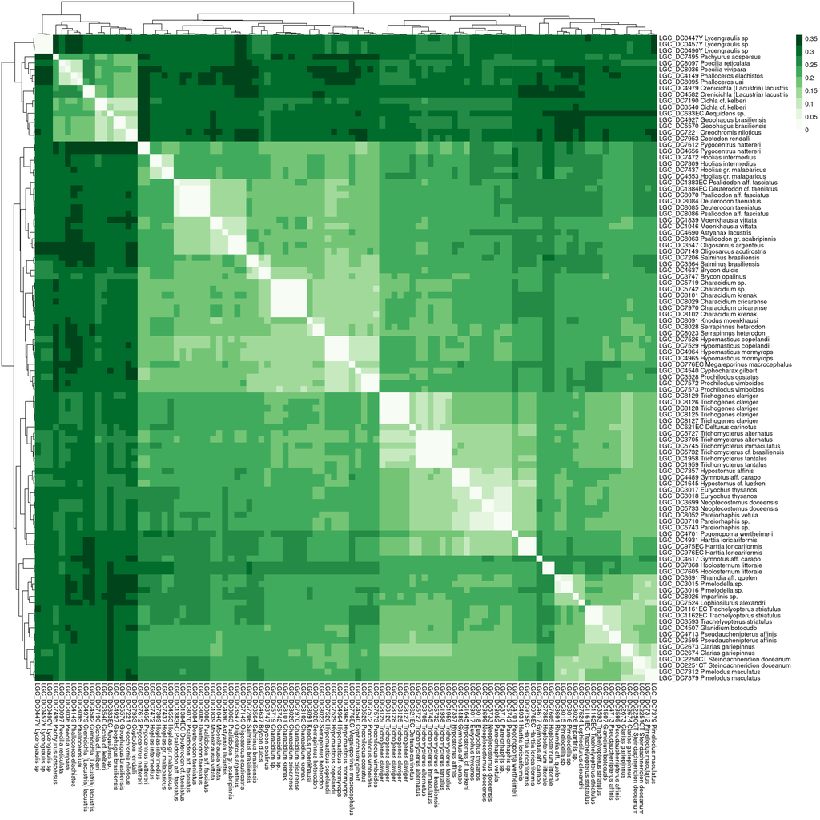

```r
# vamos ver como fica a matriz

pheatmap::pheatmap(fasta_seqs_dist,
                   fontsize = 10,
                   color = RColorBrewer::brewer.pal(n = 9,name = "Greens"))
```

### Logo de sequências

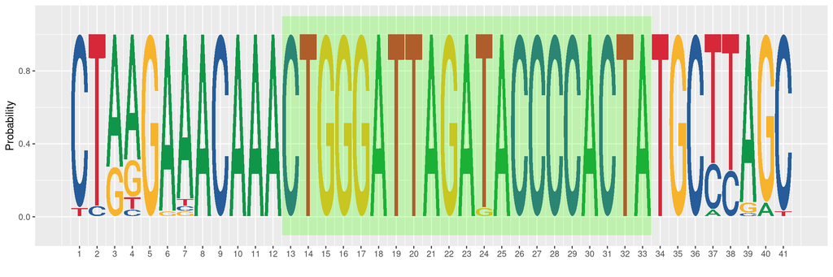

```r
## 6 -  plotar proporção de bases para uma subsequência (ggseq logo)

### a - selecionar apenas uma pequena região parcialmente conservada

fasta_sub_char <- Biostrings::subseq(fasta_seqs_alg,180,220) %>% as.character()

seqs_logo_plot <- ggplot2::ggplot() +
  ggseqlogo::geom_logo(data = fasta_sub_char,
                       method = "probability") +
  ggplot2::annotate(geom = "rect",
                    xmin = 12.5,xmax = 33.5,
                    ymin = -0.1,ymax = 1.1,
                    fill="#3cff00", alpha = 0.25)

seqs_logo_plot
```

Para salvar o gráfico como imagem na sua pasta de trabalho:

```r
ggplot2::ggsave(filename = "seqs_logo.png",
                device = "png",
                width = 30, height = 10,
                units = "cm")
```

```r
# Referências ----
# https://www.bioconductor.org/help/course-materials/2016/BioC2016/ConcurrentWorkshops2/Wright/BigBioSeqData.pdf
# https://www.bioconductor.org/packages/release/bioc/vignettes/DECIPHER/inst/doc/DECIPHERing.pdf
# http://www2.decipher.codes/RLessons/RLesson14.html
# https://besjournals.onlinelibrary.wiley.com/doi/full/10.1111/2041-210X.12687
# http://www2.decipher.codes/OligoDesign.html
# http://www2.decipher.codes/Bioinformatics/BigBioSeqData/BigBioSeqData2.html
# https://cran.r-project.org/web/packages/ggdendro/vignettes/ggdendro.html
```

E por hoje ficamos por aqui!

> > > > Voltar para a [*página inicial*](https://heronoh.github.io/bioinfo)